# Decision-Analytic Template (decisionSupport + R workflow)

Cory Whitney

### Purpose and workflow

This repository is a template for collaborating on decision models in R using {decisionSupport}.

Workflow rule: the whole project should run by knitting index.Rmd.

### Folder conventions:

data/ contains the uncertainty input table (inputs_decision.csv) and any raw data

scripts/ contains the model function and small helpers (local files)

figures/ stores exported figures (optional)

Local scripts used here:

- scripts/make_variables.R
- scripts/Decision_Model.R

### Model testing (construction helper)

This chunk builds the variables from the input table so you can test pieces of the model interactively.

```r
source("scripts/make_variables.R")
make_variables(decisionSupport::estimate_read_csv("data/inputs_decision.csv"))
```

### Check that input variables appear in the model script

This catches a common issue: the CSV contains variables that never get used in the model.

```r
data <- read.csv("data/inputs_decision.csv")
var_list <- unique(data$variable)
```

```r
r_script_lines <- readLines("scripts/Decision_Model.R")
r_script_text <- paste(r_script_lines, collapse = " ")

missing_in_script <- var_list[!sapply(var_list, function(v) grepl(v, r_script_text, fixed = TRUE))]
missing_in_script
```

```
## character(0)
```

### Monte Carlo simulation

Run the decision model under uncertainty with decisionSupport::mcSimulation().

```r
source("scripts/Decision_Model.R")

set.seed(42) # from Deep Thought

decision_simulation_results <- mcSimulation(
  estimate = estimate_read_csv("data/inputs_decision.csv"),
  model_function = decision_function,
  numberOfModelRuns = 1e4,
  functionSyntax = "plainNames"
)
```

```r
names(decision_simulation_results$y)
```

```
## [1] "NPV_decision" "Cashflow1"    "Cashflow2"    "Cashflow3"    "Cashflow4"
## [6] "Cashflow5"
```

### Core result: NPV distribution

The main output is the Net Present Value (NPV) of the decision. [^1]

```r
summary(decision_simulation_results$y$NPV_decision)
```

```
##    Min. 1st Qu.  Median    Mean 3rd Qu.    Max.
##   -7297   79401  122920  128152  172202  406656
```

```r
quantile(decision_simulation_results$y$NPV_decision, probs = c(0.05, 0.5, 0.95))
```

```
##        5%       50%       95%
##  28144.74 122919.72 242501.28
```

NPV as a density plot[^2]

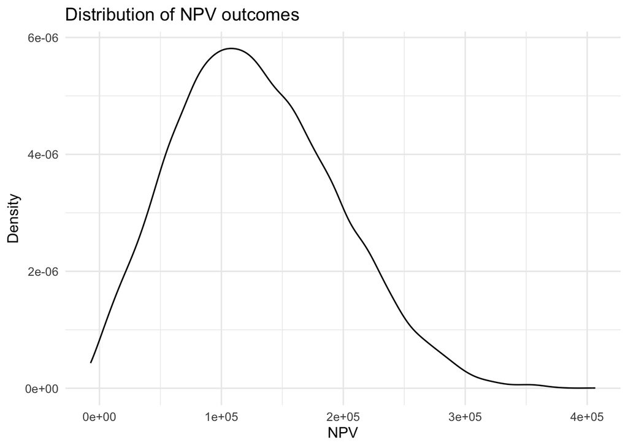

```r
df_npv <- tibble(NPV = decision_simulation_results$y$NPV_decision)


ggplot(df_npv, aes(x = NPV)) +
  geom_density() +
  labs(x = "NPV", y = "Density", title = "Distribution of NPV outcomes") +
  theme_minimal(base_size = 12)
```

NPV as a boxplot[^3]

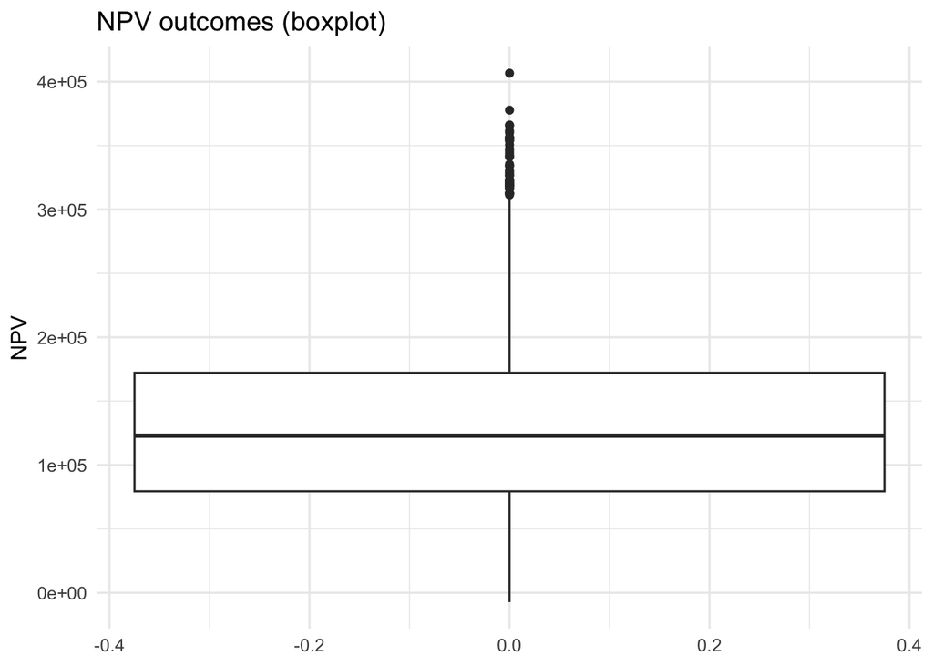

```r
ggplot(df_npv, aes(y = NPV)) +
  geom_boxplot() +
  labs(y = "NPV", title = "NPV outcomes (boxplot)") +
  theme_minimal(base_size = 12)
```

### Cashflows over time

The model returns a vector Cashflow across years. In decisionSupport, vectors are expanded into columns like Cashflow1, Cashflow2, …

```r
cashflow_cols <- grep("^Cashflow\\d+$", names(decision_simulation_results$y), value = TRUE)

cashflow_means <- tibble(
  year = seq_along(cashflow_cols),
  mean_cashflow = colMeans(decision_simulation_results$y[, cashflow_cols, drop = FALSE])
)

cashflow_means
```

```
## # A tibble: 5 × 2
##    year mean_cashflow
##   <int>         <dbl>
## 1     1        20190.
## 2     2        27616.
## 3     3        29699.
## 4     4        31945.
## 5     5        34366.
```

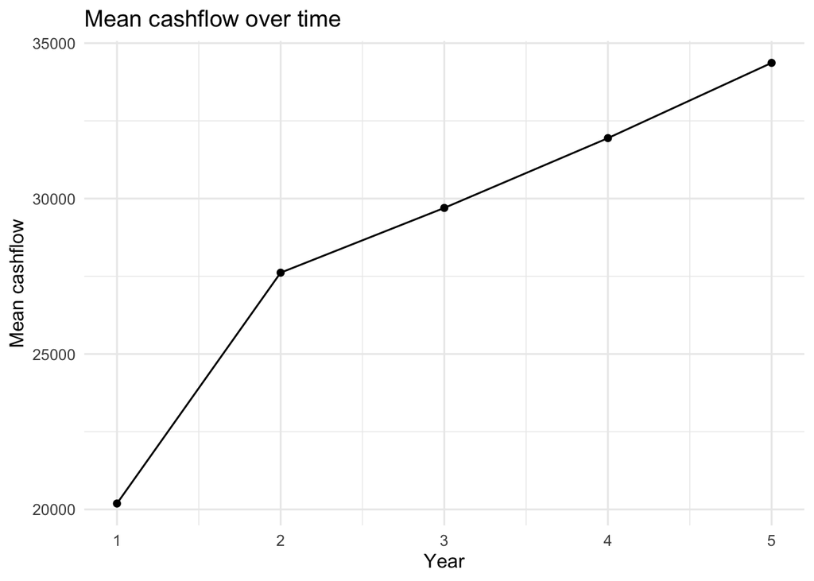

```r
ggplot(cashflow_means, aes(x = year, y = mean_cashflow)) +
  geom_line() +
  geom_point() +
  labs(x = "Year", y = "Mean cashflow", title = "Mean cashflow over time") +
  theme_minimal(base_size = 12)
```

### Input quick summary

This is a quick check of the sampled inputs used in the simulation.

```r
summary(decision_simulation_results$x)
```

```
##  number_of_years discount_rate        CV_value         inflation_rate
##  Min.   :5       Min.   : 0.3722   Min.   :0.0005933   Min.   : 1.852
##  1st Qu.:5       1st Qu.: 4.4443   1st Qu.:0.1875650   1st Qu.: 6.448
##  Median :5       Median : 5.4897   Median :0.2492753   Median : 7.517
##  Mean   :5       Mean   : 5.4825   Mean   :0.2496261   Mean   : 7.512
##  3rd Qu.:5       3rd Qu.: 6.5073   3rd Qu.:0.3113391   3rd Qu.: 8.568
##  Max.   :5       Max.   :12.0797   Max.   :0.5855435   Max.   :13.681
##  implementation_cost annual_benefit     prob_risk_event
##  Min.   :  171.4     Min.   :   53.19   Min.   :0.0006607
##  1st Qu.: 4452.1     1st Qu.:19479.75   1st Qu.:0.1863369
##  Median : 5518.2     Median :28210.17   Median :0.2487980
##  Mean   : 5496.1     Mean   :28415.78   Mean   :0.2488894
##  3rd Qu.: 6528.3     3rd Qu.:37013.82   3rd Qu.:0.3098051
##  Max.   :11392.8     Max.   :76283.39   Max.   :0.5791662
```

### Notes for collaborators

Start simple: get the project structure correct and make sure index.Rmd knits cleanly.

Keep all key steps visible in index.Rmd:

- read inputs
- run simulation
- summarize results
- generate figures

Add complexity only after the baseline model is reproducible

[^1]: We will use basic ggplot2 functions for plotting in this example but there are a number of useful plotting options in {decisionSupport}. See the [vignettes in the CRAN](https://cran.r-project.org/web/packages/decisionSupport/index.html).
[^2]: see decisionSupport::plot_distributions() for useful alternatives
[^3]: see plot_distributions `method =` options to see what else might be useful here